# Assignment 6

Nick Andriese

2022-07-24

```r
#install.packages("car","gvlma", "MASS", "leaps")
library(car)
library(gvlma)
library(MASS)
library(leaps)
```

We are going to look at the property prices for Orange County. From there we are going to try and predict the sales price by linear regression.

# 1 Importing Data

Bring in the data and make sure the data types are correct. If not, make the proper changes. The file is located within this project. *data/prop_prices_reduced.csv*

```r
library(readr)
prprice <- read_csv("prop_prices_reduced.csv")
View(prprice)
prprice$pool <- factor(prprice$pool)
```

# 2 Plotting

Plot histograms for all variables. Additionally, add scatterplots for the relationships between all quantitative variables.

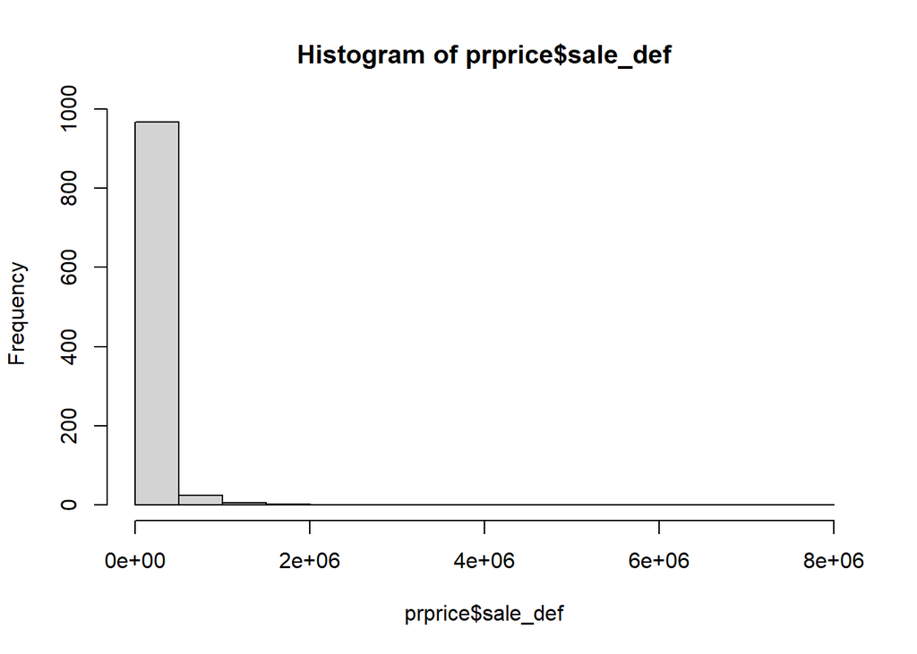

```r
library(car)
hist(prprice$sale_def)
```

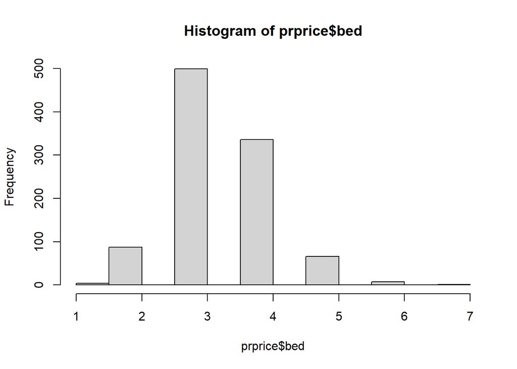

```r
hist(prprice$bed)
```

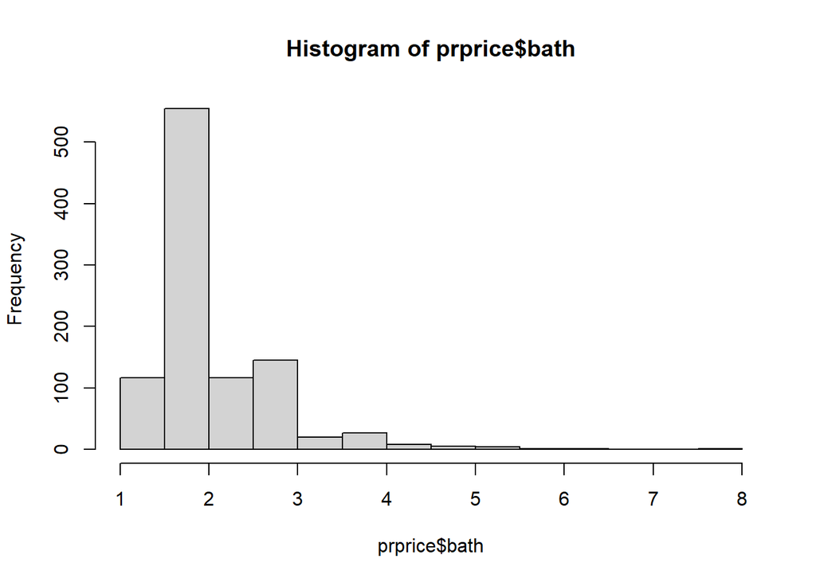

```r
hist(prprice$bath)
```

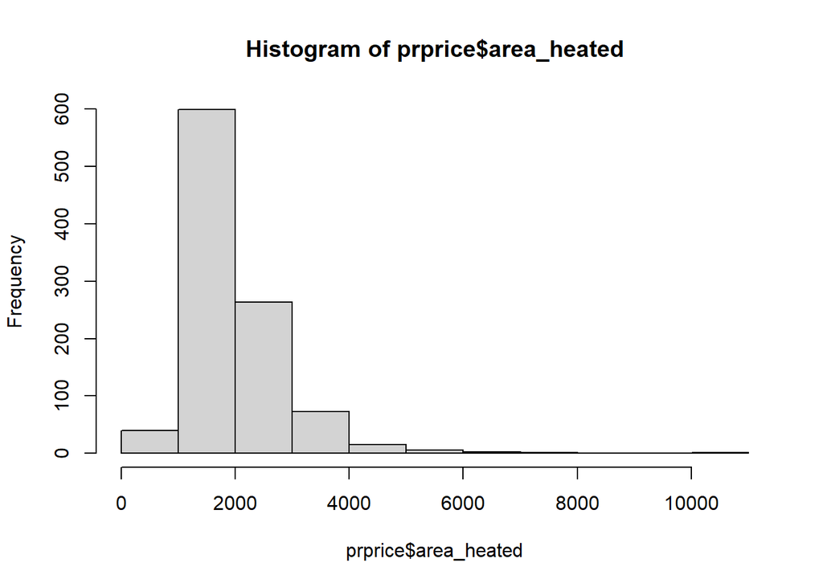

```r
hist(prprice$area_heated)
```

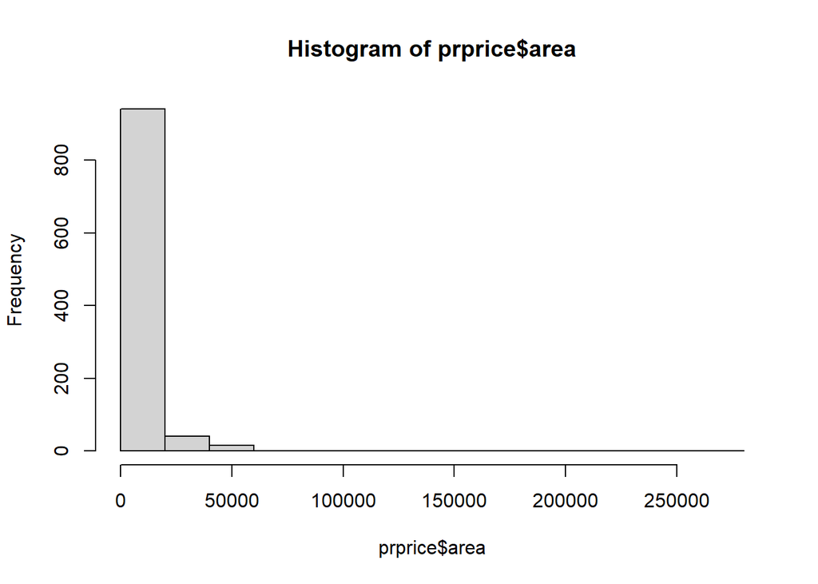

```r
hist(prprice$area)
```

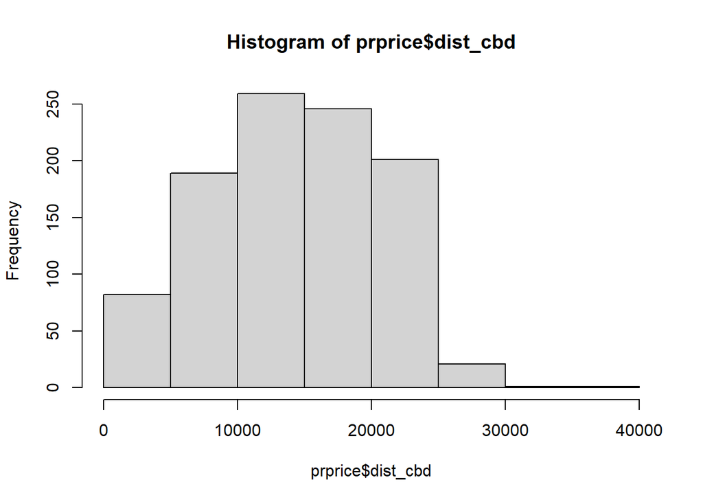

```r
hist(prprice$dist_cbd)
```

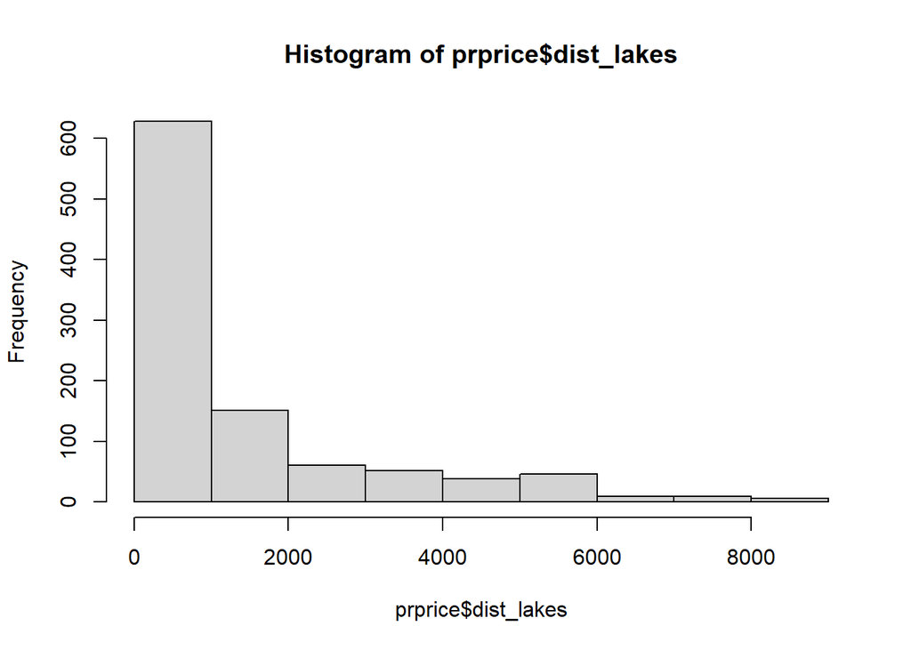

```r
hist(prprice$dist_lakes)
```

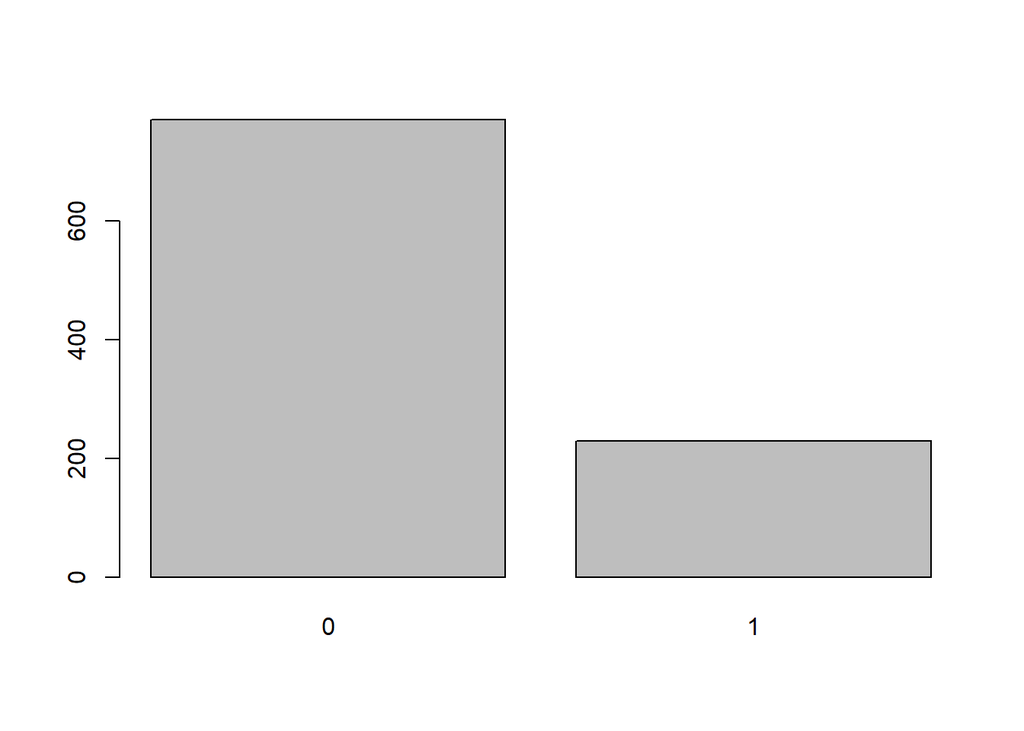

```r
plot(prprice$pool)
```

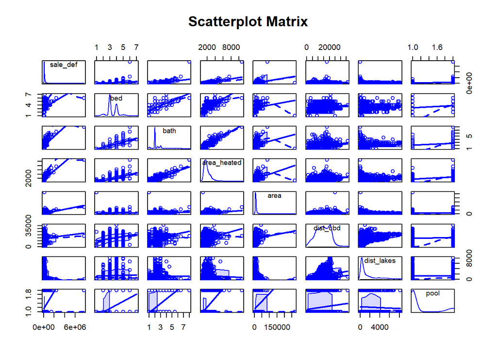

```r
scatterplotMatrix(prprice, spread = FALSE, lty.smooth = 2, main = "Scatterplot Matrix")
```

```r
prprice1 <- prprice



#excess below

# plot(prprice$bed, prprice$sale_def)
# plot(prprice$bath, prprice$sale_def)
# plot(prprice$area_heated, prprice$sale_def)
# plot(prprice$area, prprice$sale_def)
# plot(prprice$dist_cbd, prprice$sale_def)
# plot(prprice$dist_lakes, prprice$sale_def)
# plot(prprice$pool, prprice$sale_def)
# plot(prprice$bed, prprice$bath)
# plot(prprice$bed, prprice$area_heated)
# plot(prprice$bed, prprice$area)
# plot(prprice$bed, prprice$dist_cbd)
# plot(prprice$bed, prprice$dist_lakes)
# plot(prprice$bed, prprice$pool)
# plot(prprice$bath, prprice$area_heated)
# plot(prprice$bath, prprice$area)
# plot(prprice$bath, prprice$dist_cbd)
# plot(prprice$bath, prprice$dist_lakes)
# plot(prprice$bath, prprice$pool)
# plot(prprice$pool, prprice$area_heated)
# plot(prprice$pool, prprice$area)
# plot(prprice$pool, prprice$dist_cbd)
# plot(prprice$pool, prprice$dist_lakes)
# plot(prprice$area_heated, prprice$area)
# plot(prprice$area_heated, prprice$dist_cbd)
# plot(prprice$area_heated, prprice$dist_lakes)
# plot(prprice$area, prprice$dist_cbd)
# plot(prprice$area, prprice$dist_lakes)
# plot(prprice$dist_cbd, prprice$dist_lakes)
```

# 3 Summary Statistics

Provide basic summary statistics for univariate analysis. Also, provide the correlation between all the quantitative variables.

```r
#install.packages("psych")
library(psych)
summary(prprice)
```

```
##     sale_def            bed             bath        area_heated
##  Min.   :  15296   Min.   :1.000   Min.   :1.000   Min.   :  650
##  1st Qu.: 115565   1st Qu.:3.000   1st Qu.:2.000   1st Qu.: 1387
##  Median : 151085   Median :3.000   Median :2.000   Median : 1744
##  Mean   : 200319   Mean   :3.398   Mean   :2.248   Mean   : 1955
##  3rd Qu.: 213902   3rd Qu.:4.000   3rd Qu.:2.500   3rd Qu.: 2301
##  Max.   :7629992   Max.   :7.000   Max.   :8.000   Max.   :10796
##       area           dist_cbd         dist_lakes      pool
##  Min.   :  1307   Min.   :  598.2   Min.   :  16.74   0:771
##  1st Qu.:  6498   1st Qu.: 9701.7   1st Qu.: 314.86   1:229
##  Median :  8733   Median :14552.0   Median : 638.82
##  Mean   : 10565   Mean   :14382.9   Mean   :1403.54
##  3rd Qu.: 11250   3rd Qu.:19369.2   3rd Qu.:1735.35
##  Max.   :269496   Max.   :36107.6   Max.   :8206.79
```

```r
describe(prprice)
```

```
##             vars    n      mean        sd    median   trimmed      mad      min
## sale_def       1 1000 200319.25 288558.02 151085.00 164179.51 64991.99 15296.00
## bed            2 1000      3.40      0.79      3.00      3.39     1.48     1.00
## bath           3 1000      2.25      0.76      2.00      2.20     0.00     1.00
## area_heated    4 1000   1955.18    871.18   1743.50   1838.74   640.48   650.00
## area           5 1000  10565.38  11163.14   8733.00   9013.01  3551.57  1307.00
## dist_cbd       6 1000  14382.91   6136.78  14552.02  14515.73  7198.98   598.23
## dist_lakes     7 1000   1403.54   1713.86    638.82   1040.06   648.58    16.74
## pool*          8 1000      1.23      0.42      1.00      1.16     0.00     1.00
##                    max      range  skew kurtosis      se
## sale_def    7629992.00 7614696.00 18.18   442.70 9125.01
## bed               7.00       6.00  0.39     0.71    0.02
## bath              8.00       7.00  1.61     6.39    0.02
## area_heated   10796.00   10146.00  2.51    14.19   27.55
## area         269496.00  268189.00 13.81   292.73  353.01
## dist_cbd      36107.56   35509.33 -0.07    -0.64  194.06
## dist_lakes     8206.79    8190.05  1.83     2.75   54.20
## pool*             2.00       1.00  1.29    -0.34    0.01
```

```r
cor(prprice[,unlist(lapply(prprice, is.numeric))])
```

```
##                sale_def        bed        bath area_heated        area
## sale_def     1.00000000 0.32557109  0.58731596  0.69201080  0.34354392
## bed          0.32557109 1.00000000  0.64449531  0.66911599  0.10437035
## bath         0.58731596 0.64449531  1.00000000  0.83255359  0.19298319
## area_heated  0.69201080 0.66911599  0.83255359  1.00000000  0.30184325
## area         0.34354392 0.10437035  0.19298319  0.30184325  1.00000000
## dist_cbd     0.05263700 0.23328277  0.24220637  0.25494517  0.08648327
## dist_lakes  -0.08857844 0.03747888 -0.02109154 -0.04092947 -0.15432291
##               dist_cbd  dist_lakes
## sale_def    0.05263700 -0.08857844
## bed         0.23328277  0.03747888
## bath        0.24220637 -0.02109154
## area_heated 0.25494517 -0.04092947
## area        0.08648327 -0.15432291
## dist_cbd    1.00000000  0.26520451
## dist_lakes  0.26520451  1.00000000
```

# 4 Regression Analysis

Run a regression with all the variables included. Print results of the regression.

```r
model1 <- lm(sale_def ~., data = prprice)

summary(model1)
```

```
##
## Call:
## lm(formula = sale_def ~ ., data = prprice)
##
## Residuals:
##     Min      1Q  Median      3Q     Max
## -765238  -55999    9774   63848 4954827
##
## Coefficients:
##               Estimate Std. Error t value Pr(>|t|)
## (Intercept) -5.890e+04  3.093e+04  -1.904 0.057170 .
## bed         -8.492e+04  1.087e+04  -7.810 1.45e-14 ***
## bath         5.449e+04  1.507e+04   3.616 0.000315 ***
## area_heated  2.439e+02  1.430e+01  17.054  < 2e-16 ***
## area         3.548e+00  5.958e-01   5.955 3.61e-09 ***
## dist_cbd    -5.848e+00  1.090e+00  -5.366 1.00e-07 ***
## dist_lakes   9.651e-01  3.810e+00   0.253 0.800091
## pool1       -2.776e+04  1.640e+04  -1.693 0.090787 .
## ---
## Signif. codes:  0 '***' 0.001 '**' 0.01 '*' 0.05 '.' 0.1 ' ' 1
##
## Residual standard error: 194900 on 992 degrees of freedom
## Multiple R-squared:  0.547,  Adjusted R-squared:  0.5438
## F-statistic: 171.2 on 7 and 992 DF,  p-value: < 2.2e-16
```

Which of the variables tested significant at the 95% level? Looking at the results and answering outside of the chunk is sufficient.

*bed, bath, area_heated, area, dist_cbd all tested significant above the the 95% level*

## 4.1 Evaluating the model

As is, are any of the Gauss-Markov assumptions violated? If so, which ones? How can you fix the issues?

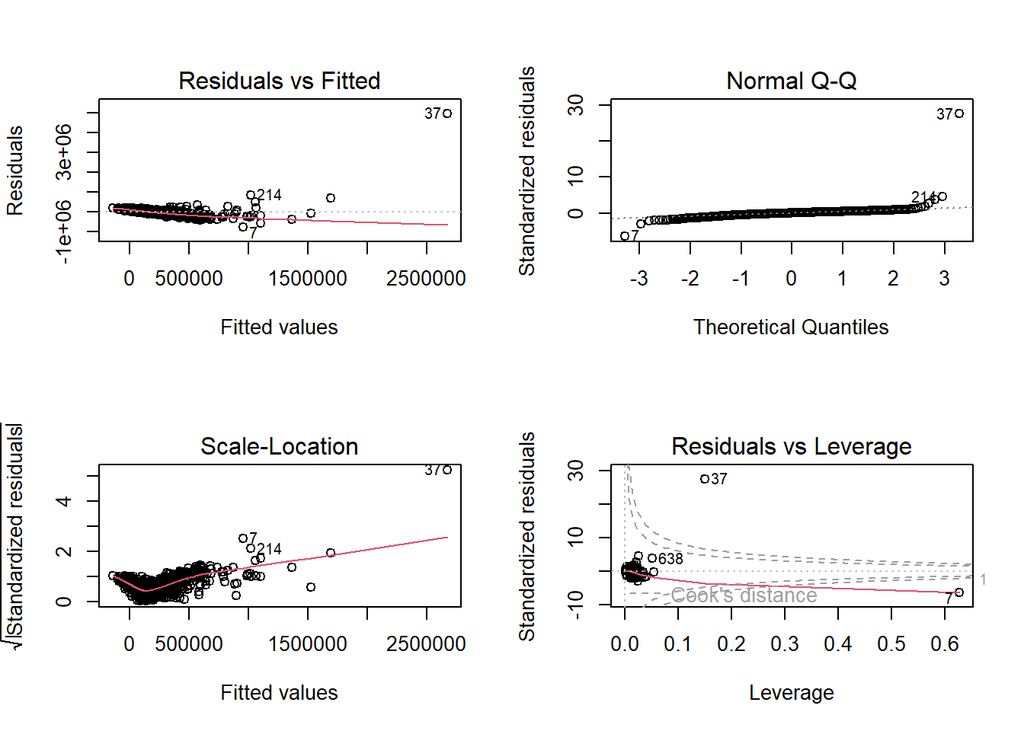

```r
#Regression diagnostics
opar <- par(no.readonly = TRUE)
par(mfrow =c(2, 2))
plot(model1)
```

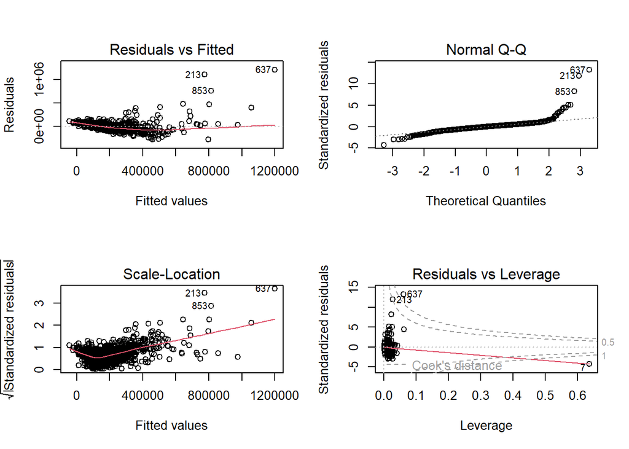

```r
###only seems like #37 is vast outlier, in trending downward on residuals

newmodel1 <- lm(sale_def ~., data = prprice[-c(37),])
plot(newmodel1)
```

```r
### without 37 included

#Normality
qqPlot(model1, labels=FALSE, simulate = TRUE, main = "Q-Q Plot")
```

```
## [1]  7 37
```

```r
qqPlot(newmodel1, labels=FALSE, simulate = TRUE, main = "Q-Q Plot")
```

```
## [1] 213 637
```

```r
###appears to start curling around the tails, non-normal

#autocorrelated erros
durbinWatsonTest(model1)
```

```
##  lag Autocorrelation D-W Statistic p-value
##    1    -0.008920317      2.017485    0.74
##  Alternative hypothesis: rho != 0
```

```r
durbinWatsonTest(newmodel1)
```

```
##  lag Autocorrelation D-W Statistic p-value
##    1      0.01920489      1.961551    0.48
##  Alternative hypothesis: rho != 0
```

[figure not shown]

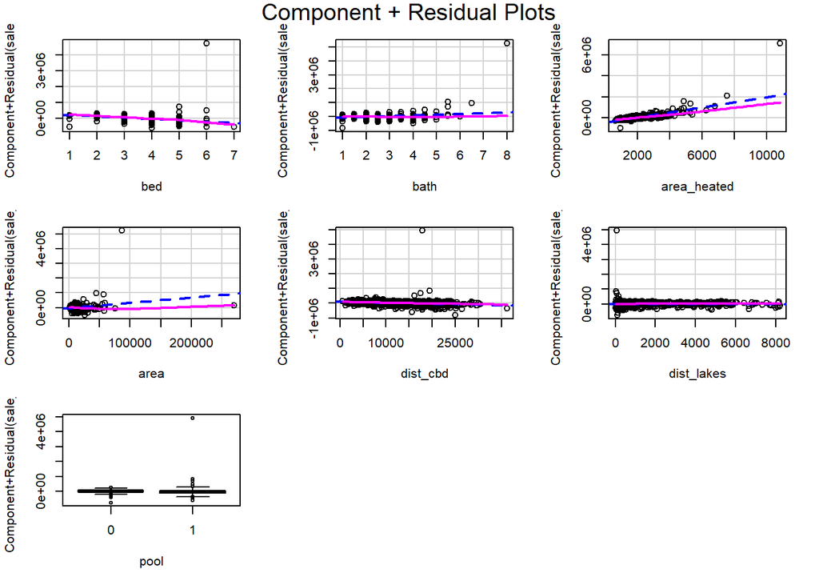

```r
###not significant, no autocorrelation of errors

#what does this test???
crPlots(model1, one.page = TRUE, ask = FALSE)
```

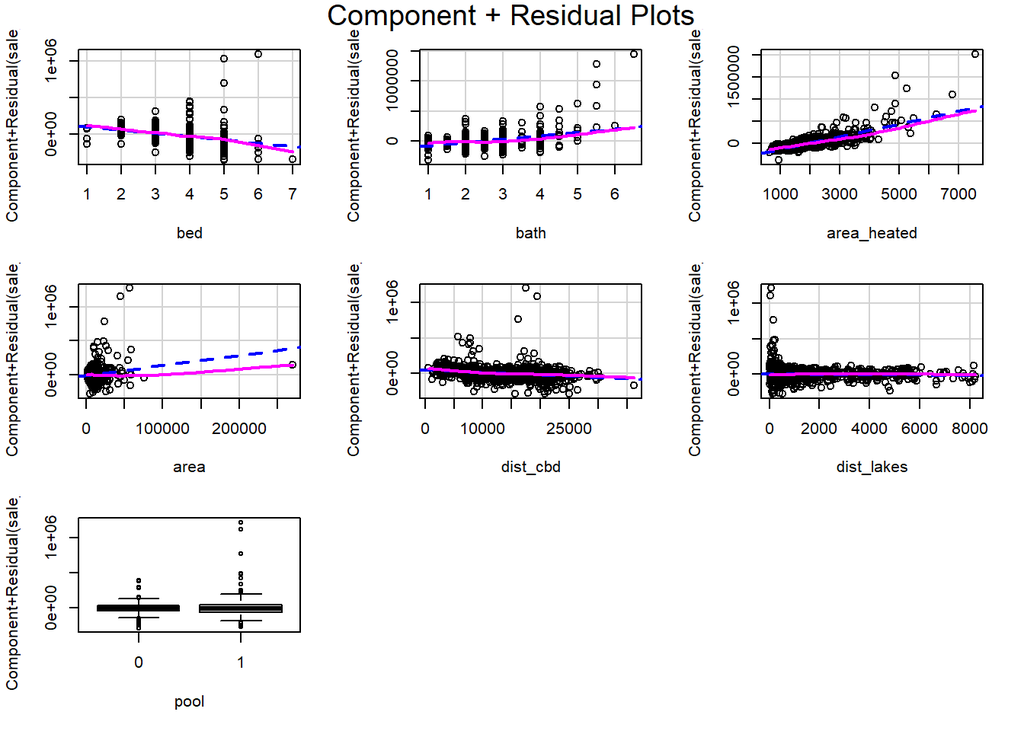

```r
crPlots(newmodel1, one.page = TRUE, ask = FALSE)
```

```r
#Heteroskedasticity diagnostic:
ncvTest(model1)
```

```
## Non-constant Variance Score Test
## Variance formula: ~ fitted.values
## Chisquare = 32709.06, Df = 1, p = < 2.22e-16
```

```r
ncvTest(newmodel1)
```

```
## Non-constant Variance Score Test
## Variance formula: ~ fitted.values
## Chisquare = 4285.545, Df = 1, p = < 2.22e-16
```

```r
###both models indicate heteroskedasticity
###What should I do to correct for it? the power?
spreadLevelPlot(model1)
```

[output not shown]

```
##
## Suggested power transformation:  0.8407828
```

```r
#heteroskedastic

#gvlma
library(gvlma)
gvmodel1 <- gvlma(model1)
summary(gvmodel1)
```

```
##
## Call:
## lm(formula = sale_def ~ ., data = prprice)
##
## Residuals:
##     Min      1Q  Median      3Q     Max
## -765238  -55999    9774   63848 4954827
##
## Coefficients:
##               Estimate Std. Error t value Pr(>|t|)
## (Intercept) -5.890e+04  3.093e+04  -1.904 0.057170 .
## bed         -8.492e+04  1.087e+04  -7.810 1.45e-14 ***
## bath         5.449e+04  1.507e+04   3.616 0.000315 ***
## area_heated  2.439e+02  1.430e+01  17.054  < 2e-16 ***
## area         3.548e+00  5.958e-01   5.955 3.61e-09 ***
## dist_cbd    -5.848e+00  1.090e+00  -5.366 1.00e-07 ***
## dist_lakes   9.651e-01  3.810e+00   0.253 0.800091
## pool1       -2.776e+04  1.640e+04  -1.693 0.090787 .
## ---
## Signif. codes:  0 '***' 0.001 '**' 0.01 '*' 0.05 '.' 0.1 ' ' 1
##
## Residual standard error: 194900 on 992 degrees of freedom
## Multiple R-squared:  0.547,  Adjusted R-squared:  0.5438
## F-statistic: 171.2 on 7 and 992 DF,  p-value: < 2.2e-16
##
##
## ASSESSMENT OF THE LINEAR MODEL ASSUMPTIONS
## USING THE GLOBAL TEST ON 4 DEGREES-OF-FREEDOM:
## Level of Significance =  0.05
##
## Call:
##  gvlma(x = model1)
##
##                        Value p-value                   Decision
## Global Stat        7497980.4       0 Assumptions NOT satisfied!
## Skewness             45659.6       0 Assumptions NOT satisfied!
## Kurtosis           7450926.5       0 Assumptions NOT satisfied!
## Link Function          782.2       0 Assumptions NOT satisfied!
## Heteroscedasticity     612.1       0 Assumptions NOT satisfied!
```